# 의료데이터 분석

뉴스와 코로나19 확진자 사이의 연관성 조사

1. 코로나19 관련 뉴스 개수가 코로나19 확진자에 영향을 줄까? (가설 : 영향을 줄 것이다.)
2. 뉴스가 코로나19 확진자에 영향을 준다면, 시기가 지남에 따라서 코로나19 확진자 수에 대한 뉴스의 영향이 달라질까?? (가설 : 달라질 것이다. 일주일 정도 지나야지 코로나19 확진자에 영향을 줄것이다.)
3. 부정적인 키워드와 긍정적인 키워드의 뉴스 개수 차이가 코로나확진자수에 영향을 줄까? (가설 : 영향을 줄 것이다.)

```python
import pandas as pd
import numpy as np
import urllib.request as ul
import xmltodict
import json
import sys
import io
import pandas as pd
import xml.etree.ElementTree as ET
import matplotlib.pyplot as plt
from datetime import datetime
import seaborn as sns
import scipy as sp
import scipy.stats as stats
```

뉴스데이터 받아오기(엑셀)

긍정적 키워드 - news_c, news_d, news_f

```python
news_a = pd.read_excel('NewsResult_20200501-20210423(폭증).xlsx')
news_b = pd.read_excel('NewsResult_20200501-20210423(사망, 위험).xlsx')
news_c = pd.read_excel('NewsResult_20200501-20210423(백신, 안정).xlsx')
news_d = pd.read_excel('NewsResult_20200501-20210423(확진자, 감소세).xlsx')
news_e = pd.read_excel('NewsResult_20200501-20210423(확진자, 증가세).xlsx')
news_f = pd.read_excel('NewsResult_20200501-20210423(완치).xlsx')
```

```python
#뉴스 데이터를 개수로 정리하기

news_a1 = pd.to_numeric(news_a.groupby('일자').count().제목)
news_a1.index = pd.date_range(start = '20200501', end = '20210421')
news_b1 = pd.to_numeric(news_b.groupby('일자').count().제목)
news_b1.index = pd.date_range(start = '20200501', end = '20210422')
news_c1 = pd.to_numeric(news_c.groupby('일자').count().제목)
news_c1.index = pd.date_range(start = '20200501', end = '20210423')
news_d1 = pd.to_numeric(news_c.groupby('일자').count().제목)
news_d1.index = pd.date_range(start = '20200501', end = '20210423')
news_e1 = pd.to_numeric(news_c.groupby('일자').count().제목)
news_e1.index = pd.date_range(start = '20200501', end = '20210423')
news_f1 = pd.to_numeric(news_c.groupby('일자').count().제목)
news_f1.index = pd.date_range(start = '20200501', end = '20210423')

#부정적인 키워드, 긍정적인 키워드를 담은 뉴스 개수를 합해준다.

news_n = news_e1 + news_b1 + news_a1
news_n = news_n.rename('negative_news')

news_p = news_c1 + news_d1 + news_f1
news_p = news_p.rename('positive_news')

news_total = news_p + news_n
news_total = news_total.rename('total_news')
```

코로나 확진자 데이터 읽어오기(open api 활용, 받아온 데이터를 엑셀파일로 정리)

and 일별 확진자 수 확인을 위해서 새로운 행을 생성

```python
url = 'http://openapi.data.go.kr/openapi/service/rest/Covid19/getCovid19InfStateJson?serviceKey=aCUC%2FTLCuyGnNlPOC47aWKgwv731EgDTG6AOu85uEfx5BNQ9pQNI1Pvc3xiqtd8O2Qf4%2BxLfvcmZygDFGR4dBw%3D%3D&startCreateDt=20200501&endCreateDt=20210424'

request = ul.Request(url)

response = ul.urlopen(request)

response_data = response.read()

plt.figure(figsize=(50, 30))
Data_c = xmltodict.parse(response_data)
Data_c = Data_c['response']['body']['items']['item']
Data_c = pd.DataFrame.from_dict(Data_c)


Data_c1 = Data_c[::-1]
Data_c1['decideCnt'] = pd.to_numeric(Data_c1['decideCnt'])
Data_c1.sort_values(by = ['stateDt'], inplace = True)

Data_c1['Diff'] = Data_c1.decideCnt.diff()
Data_c1 = Data_c1.set_index('stateDt')
```

```python
Data_c1.set_index(pd.date_range(start = '20200501', end = '20210424'), inplace=True)
Data_c1
```

|  | accDefRate | accExamCnt | accExamCompCnt | careCnt | clearCnt | createDt | deathCnt | decideCnt | examCnt | resutlNegCnt | seq | stateTime | updateDt | Diff |
| --- | --- | --- | --- | --- | --- | --- | --- | --- | --- | --- | --- | --- | --- | --- |
| 2020-05-01 | 1.7536263965 | 623069 | 614384 | 1459 | 9072 | 2020-05-01 10:24:38.38 | 248 | 10774 | 8685 | 603610 | 125 | 00:00 | 2020-05-01 10:24:38.38 | NaN |
| 2020-05-02 | 1.7413329111 | 627562 | 619066 | 1454 | 9123 | 2020-05-02 10:22:19.19 | 250 | 10780 | 8496 | 608286 | 126 | 00:00 | 2020-05-02 10:22:19.19 | 6.0 |
| 2020-05-03 | 1.7341356234 | 630973 | 622385 | 1407 | 9183 | 2020-05-03 10:54:37.37 | 250 | 10793 | 8588 | 611592 | 127 | 00:00 | 2020-05-03 10:54:37.37 | 13.0 |
| 2020-05-04 | 1.7261024858 | 633921 | 625745 | 1360 | 9217 | 2020-05-04 10:11:32.32 | 252 | 10801 | 8176 | 614944 | 128 | 00:00 | 2020-05-04 10:11:32.32 | 8.0 |
| 2020-05-05 | 1.7111750628 | 640237 | 631379 | 1332 | 9283 | 2020-05-05 10:20:41.41 | 254 | 10804 | 8858 | 620575 | 129 | 00:00 | 2020-05-05 10:20:41.41 | 3.0 |
| ... | ... | ... | ... | ... | ... | ... | ... | ... | ... | ... | ... | ... | ... | ... |
| 2021-04-20 | 1.3726760312 | 8458592 | 8392002 | 8166 | 105227 | 2021-04-20 09:34:02.801 | 1802 | 115195 | 66590 | 8276807 | 486 | 00:00 | null | 549.0 |
| 2021-04-21 | 1.3750976675 | 8497594 | 8430383 | 8243 | 105877 | 2021-04-21 09:36:56.675 | 1806 | 115926 | 67211 | 8314457 | 488 | 00:00 | null | 731.0 |
| 2021-04-22 | 1.3772840512 | 8537505 | 8470366 | 8394 | 106459 | 2021-04-22 09:31:58.246 | 1808 | 116661 | 67139 | 8353705 | 489 | 00:00 | null | 735.0 |
| 2021-04-23 | 1.3796528397 | 8583530 | 8513591 | 8576 | 107071 | 2021-04-23 09:51:40.55 | 1811 | 117458 | 69939 | 8396133 | 490 | 00:00 | null | 797.0 |
| 2021-04-24 | 1.3822066912 | 8632923 | 8554654 | 8650 | 107781 | 2021-04-24 09:38:23.778 | 1812 | 118243 | 78269 | 8436411 | 491 | 00:00 | null | 785.0 |

359 rows × 14 columns

```python
def date_p(str_date, i) :
    if((str_date + i)%100>30):
        str_date = str_date-(str_date%100) + 100 + ( i - 7 )
    else :
        str_date = str_date + i
    return str_date
```

과연 코로나 관련 뉴스는 몇일이 지나야 사람들에게 영향을 주는 것일까?(2번 질문) 코로나 발현시까지의 기간, 뉴스를 확인하고 생활속 변화가 생기는 기간

#### 개선사항 : 코로나19 확진자가 진단소가 휴식을 가지는 주말때의 결과가 나오는 월요일,화요일에 무조건 적게 나오는 요인을 고려하여 분석에 방해가 될 것이라 판단하여 이 부분을 제거하고 데이터 분석을 진행하였다.

```python
R_n = []
R_p = []
R_t = []
p_n = []
p_p = []
p_t = []
for i in range(0,17) :
    news_n.index = pd.date_range(start = str(date_p(20200501, i)), end = str(date_p(20210423, i)))
    news_p.index = pd.date_range(start = str(date_p(20200501, i)), end = str(date_p(20210423, i)))
    news_total.index = pd.date_range(start = str(date_p(20200501, i)), end = str(date_p(20210423, i)))
    Data_all = pd.concat([Data_c1.Diff, news_n, news_p, news_total], axis=1)
    Data_all.dropna(inplace = True)
    Data_all2 = Data_all[Data_all.index.weekday > 1]
    [R_nt, p_nt] = stats.pearsonr(Data_all2.Diff, Data_all2.negative_news)
    R_n.append(R_nt)
    p_n.append(p_nt)
    [R_pt, p_pt] = stats.pearsonr(Data_all2.Diff, Data_all2.positive_news)
    R_p.append(R_pt)
    p_p.append(p_pt)
    [R_tt, p_tt] = stats.pearsonr(Data_all2.Diff, Data_all2.total_news)
    R_t.append(R_tt)
    p_t.append(p_tt)
```

```python
#지나간 날짜에 따른 뉴스와 확진자의 상관관계 정리

daily_total_R = pd.DataFrame(list([R_n, R_p, R_t])).transpose()
daily_total_R = daily_total_R.rename(columns={0 : 'R_negative', 1 : 'R_positive', 2 : 'R_total'})
daily_total_p = pd.DataFrame(list([p_n, p_p, p_t])).transpose()
daily_total_p = daily_total_p.rename(columns={0 : 'p_negative', 1 : 'p_positive', 2 : 'p_total'})
```

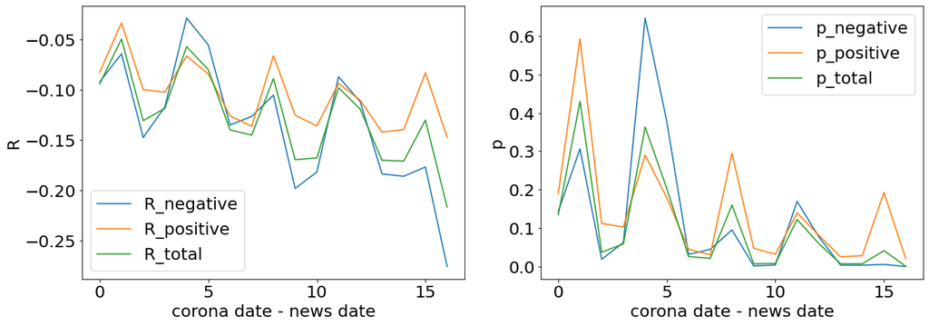

```python
fig, ax1 = plt.subplots()

plt.subplot(121)
plt.plot(daily_total_R)
plt.legend(['R_negative', 'R_positive', 'R_total'])
plt.xlabel('corona date - news date')
plt.ylabel('R')

plt.subplot(122)
plt.plot(daily_total_p)
plt.legend(['p_negative', 'p_positive', 'p_total'])
plt.xlabel('corona date - news date')
plt.ylabel('p')

fig.set_figwidth(18)
fig.set_figheight(6)
plt.rc('font', size=20)

#p 값이 2일, 7, 10, 13일쯤 낮아지는 것을 확인할 수 있다.
#그 이후의 기간은(15일 이상) 상관관계가 적을거라 판단하였음.
```

#### 개선사항 : 그래프의 효과적인 시각화를 위해서 p값과 R값을 나타내는 그래프를 따로 분리하여 나타냈고, xticks, yticks, legend 텍스트를 추가하였다.

```python
R_n1 = []
R_p1 = []
R_t1 = []
p_n1 = []
p_p1 = []
p_t1 = []


for i in range(0,17) :
    news_n.index = pd.date_range(start = str(date_p(20200501, i)), end = str(date_p(20210423, i)))
    news_p.index = pd.date_range(start = str(date_p(20200501, i)), end = str(date_p(20210423, i)))
    news_total.index = pd.date_range(start = str(date_p(20200501, i)), end = str(date_p(20210423, i)))
    Data_all = pd.concat([Data_c1.Diff, news_n, news_p, news_total], axis=1)
    Data_all.dropna(inplace = True)
    Data_all2 = Data_all[Data_all.index.weekday > 1]
    [R_nt, p_nt] = stats.spearmanr(Data_all2.Diff, Data_all2.negative_news)
    R_n1.append(R_nt)
    p_n1.append(p_nt)
    [R_pt, p_pt] = stats.spearmanr(Data_all2.Diff, Data_all2.positive_news)
    R_p1.append(R_pt)
    p_p1.append(p_pt)
    [R_tt, p_tt] = stats.spearmanr(Data_all2.Diff, Data_all2.total_news)
    R_t1.append(R_tt)
    p_t1.append(p_tt)
```

```python
daily_total_R1 = pd.DataFrame(list([R_n1, R_p1, R_t1])).transpose()
daily_total_R1 = daily_total_R1.rename(columns={0 : 'R_negative', 1 : 'R_positive', 2 : 'R_total'})
daily_total_p1 = pd.DataFrame(list([p_n1, p_p1, p_t1])).transpose()
daily_total_p1 = daily_total_p1.rename(columns={0 : 'p_negative', 1 : 'p_positive', 2 : 'p_total'})
```

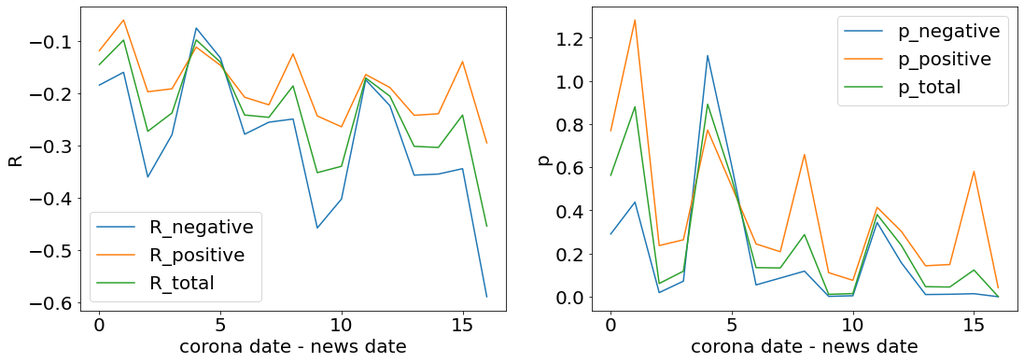

```python
fig, ax1 = plt.subplots()

daily_total_R1 = daily_total_R1 + daily_total_R
daily_total_p1 = daily_total_p1 + daily_total_p


plt.subplot(121)
plt.plot(daily_total_R1)
plt.legend(['R_negative', 'R_positive', 'R_total'])
plt.xlabel('corona date - news date')
plt.ylabel('R')

plt.subplot(122)
plt.plot(daily_total_p1)
plt.legend(['p_negative', 'p_positive', 'p_total'])
plt.xlabel('corona date - news date')
plt.ylabel('p')

fig.set_figwidth(18)
fig.set_figheight(6)
plt.rc('font', size=20)

#p 값이 2일, 7, 10, 13일쯤 낮아지는 것을 확인할 수 있다.
#그 이후의 기간은(15일 이상) 상관관계가 적을거라 판단하였음.
```

#### 개선사항 : 그래프의 효과적인 시각화를 위해서 p값과 R값을 나타내는 그래프를 따로 분리하여 나타냈고, xticks, yticks, legend 텍스트를 추가하였다.

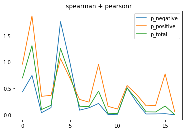

```python
plt.plot(daily_total_p1 + daily_total_p)
plt.legend(['p_negative', 'p_positive', 'p_total'])
plt.title('spearman + pearsonr')
fig.set_figwidth(18)
fig.set_figheight(6)
plt.rc('font', size=20)
```

#### 개선사항 : 10일이라는 결과는 개선사항을 적용한 결과 바뀌어 나타나게 된 결과값이다. 기존의 분석은 6일차이가 기준이었다.

아래 그래프는 확진자와 부정적,긍정적 키워드를 담은 뉴스 개수 그래프(1번질문) 이다.

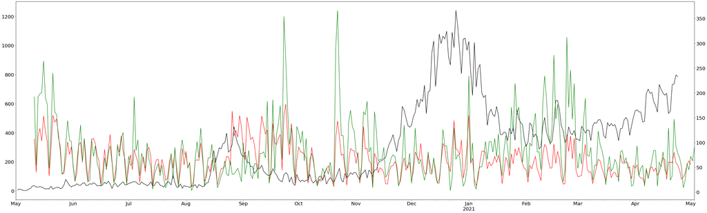

```python
#위의 결과를 고려해서 10일 차이를 주기로 하였다.
news_total.index = pd.date_range(start = '20200511', end = '20210503')
news_p.index = pd.date_range(start = '20200511', end = '20210503')
news_n.index = pd.date_range(start = '20200511', end = '20210503')

fig, ax1 = plt.subplots()
ax2 = ax1.twinx()
Data_c1.Diff.plot(ax = ax1, color='black')
news_n.plot(ax = ax2, color = 'red')
news_p.plot(ax = ax2, color = 'green')
#news_total.plot(ax=ax2)

fig.set_figwidth(50)
fig.set_figheight(15)
plt.xlim([datetime(2020,5,1), datetime(2021,5,3)])
plt.rc('font', size=50)
```

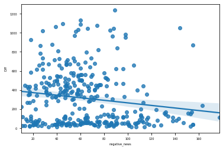

```python
sns.regplot(data = Data_all, x = 'negative_news', y = 'Diff')
plt.rc('font', size=5)
```

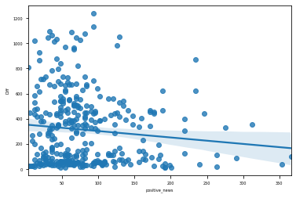

```python
sns.regplot(data = Data_all, x = 'positive_news', y = 'Diff')
plt.rc('font', size=5)
```

```python
#(3)

[R2, p2] = stats.spearmanr(Data_all.Diff, Data_all.negative_news)
print('negative_news_spearman')
print([R2, p2])

[R2, p2] = stats.spearmanr(Data_all.Diff, Data_all.positive_news)
print('positive_news_spearman')
print([R2, p2])

[R2, p2] = stats.spearmanr(Data_all.Diff, Data_all.total_news)
print('total_news_spearman')
print([R2, p2])

[R2, p2] = stats.pearsonr(Data_all.Diff, Data_all.negative_news)
print('negative_news_pearson')
print([R2, p2])

[R2, p2] = stats.pearsonr(Data_all.Diff, Data_all.positive_news)
print('positive_news_pearson')
print([R2, p2])

[R2, p2] = stats.pearsonr(Data_all.Diff, Data_all.total_news)
print('total_news_pearson')
print([R2, p2])

[R2, p2] = stats.pearsonr(Data_all.negative_news, Data_all.positive_news)
print('negative_news_positive_news_pearson')
print([R2, p2])
```

```
negative_news_spearman
[-0.1470622311370473, 0.00636156264740875]
positive_news_spearman
[-0.058894422227852884, 0.2767263949702188]
total_news_spearman
[-0.10274949651024883, 0.05729742837078087]
negative_news_pearson
[-0.1595343757710917, 0.003048241132419197]
positive_news_pearson
[-0.10723922835107882, 0.0471918206126186]
total_news_pearson
[-0.13713492514411246, 0.011005444182393923]
negative_news_positive_news_pearson
[0.6663577375235974, 2.1921559391824648e-45]
```

### 코로나 관련 뉴스가 많을수록 확진자가 적어지는 현상이 나타난다.(1)

### 부정적인 키워드가 긍정적인 키워드보다 상대적으로 영향을 많이 주는 것을 확인할 수 있다. (3)

### 10일쯤에 코로나19 관련 뉴스 수의 변화가 코로나 확진자 수 변화에 가장 영향을 줄 확률이 높음. (2)

### 부정적, 긍정적 키워드와 상관없이 코로나 뉴스 자체가 많이 나오는 날이 있음.

개선점

#### 확진자가 외부요인(주말에 확진자가 적게 나타날 수 밖에 없음 등등)으로 인해서 바뀌는 점을 인지못함. 기준일수를 정하는 근거가 부족함.

#### 서로 연관없는 그래프는 효과적인 시각화를 위해서 따로 쓰기

#### 그래프가 더 알아보기 쉽도록 xlabel, legend 등 정리해놓기

#### 코드 이해를 쉽게 하기 위해서 소제목 추가하기